# Data Wrangling

For Stoat control in Beech forest paper

Anthony Davidson

2019-05-16

# Overview

This report investigates the estimation of the raw observations. The data is in a similar structure as historically used for estimation of food availability (Choquenot and Ruscoe 2000; Ruscoe, Goldsmith, and Choquenot 2001; Ruscoe et al. 2005).

# Introduction and Methods

*Generally look at thesis drafts here.*

This RMarkdown file is intend to be extended on for different species of trees, fruit and seed. These files are the supporting documetation to the data-wrangling code in the Beech forest manuscript here.

## Tidyverse

To aviod issues with factors and data management I have used the following pre-print publications authored by the creators of `dplyr` and `ggplot2`. Tidyverse is a group of packages that together make use a `tidy` approach effective.

Here is some more information about the tidyverse approach

## Meta-data

- [Current draft](https://www.dropbox.com/home/phd-drafts-anthony/beech-forest-dynamics/drafts/Davidson_2019_BeechForest.html)
- [Style sheet](https://www.dropbox.com/home/phd-drafts-anthony/beech-forest-dynamics/Styles_manual_sheet.md/)
- [Introduction](https://www.dropbox.com/sh/5h4mp67p7u6t1lj/AAAQVKS4qnvu2oQLu53JQUofa?dl=0)
- [Bayesian methods](https://www.dropbox.com/home/phd-drafts-anthony/beech-forest-dynamics/A1_full_bayesian_model.pdf)
- [Figures](https://www.dropbox.com/home/phd-drafts-anthony/beech-forest-dynamics/figs)
- [Functional response](https://www.dropbox.com/home/phd-drafts-anthony/beech-forest-dynamics/Davidson_2019_BeechForest_Appendix.pdf)
- References: *coming online soon*

All other data and resources to render project from raw data (copied from my private GIT repository) can be found on [dropbox](https://www.dropbox.com/home/phd-drafts-anthony) but will be available here when I have incorporated the co-authors feedback

## Variable structure

I have defined the following parameters that help to keep the type of variable the same throughout the joining of the raw data and the model outputs.

### Group levels

THis has been hard to do with as little manual mistakes in factor levels as possible. The levelling structure should be the same throughout this document as descripted in beech data above.

*But in short*

#### Labels/levels

*all mixed up* **still**

```r
#month levels to get it right
month_levels <- c("Jan", "Feb", "Mar", "Apr", "May", "Jun","Jul", "Aug", "Sep", "Oct", "Nov", "Dec")

# full set of dates
true.date <- as.Date(c("1999-05-01","1999-08-01","1999-11-01","2000-02-01","2000-05-01","2000-08-01","2000-11-01","2001-02-01","2001-05-01","2001-08-01", "2001-11-01","2002-05-01","2002-11-01","2003-02-01","2003-05-01","2003-08-01","2003-11-01","2004-02-01","2004-05-01","2004-08-01"))

# Grid labels
labels <- c("egl M1" = "Grid one",
            "egl M2" = "Grid two",
            "egl MR1" = "Grid three",
            "egl MR2" = "Grid four",
            "hol M1" = "Grid five",
            "hol M2" = "Grid six",
            "hol MR1" = "Grid seven",
            "hol MR2" = "Grid eight")

# Valley labels
labels2 <- c(egl = "Eglinton valley", hol = "Hollyford valley")
```

##### Full treatment

**6 levels**

```r
treat.six.levels <- c("hol no control rats.removed",
                                     "hol control rats.present",
                                     "hol control rats.removed",
                                     "egl control rats.present",
                                     "egl control rats.removed" ,
                                     "hol no control rats.present")
```

In this the structure of the variables for the seed dataset have to be joint and visualised we need to insure that there are the same number of replicates in this dataset as the output dataset (from the JAGS model).

##### Still coming out of wash

COntrol labels - Stoats yes/no

Conditions labals - Rats yes/no

### Seasonal factorisation

In the data the seasonal parameter is month where:

| Month | Season | Factor level |
| --- | --- | --- |
| February | Summer | 1 |
| May | Autumn | 2 |
| August | Winter | 3 |
| November | Spring | 4 |

# Seeds

This is important because the following bias are known and need to be accounted for before analysising data.

1. Seeds without the kernal have no energy value and need to be removed.
2. Different beech species produce different sized seeds and this has an effect on the “available seed”.
3. As our models build in complexity we will include a variety of food resources and therefore need to model these relationships in the future

## Importing data

The orginal data was in excel format and manually covered to csv as below. This has had the non-viable material removed and only whole kernals of seed for three species of beech tree were reported.

### Seed Measurement

The data is very clean with all the information but to make life simplier for the analysis and bindng to output data to be correct.

#### Method - `metre sq (m2)`

1. `Bucket radius = 0.125m`
2. `Bucket area = 0.049087385m2`
3. `4 buckets per grid = total catch area = 0.19635 m2`
4. `So seeds /m2 =# Seeds counted/0.1963`

Therefore, if $800$ seeds were counted on a grid on a particular trip, this will equate to $4000 m^2$.

### Find extra trips and grids

### Remove additional data

## Final seed dataset

This is the full raw data reduction for the publication and in all the analysis. This data is lagged by a single trip (as a proxy for seed to “intake rate” relationship). Descriptive plots can be found in appendix.

```
# A tibble: 144 x 13
# Groups:   grid, year [44]
   valley   red silver seedm2 grid.id grid  trip.no  year month total
   <chr>  <dbl>  <dbl>  <dbl> <chr>   <chr>   <dbl> <dbl> <fct> <dbl>
 1 egl       81     31  591.  M1      egl ~       1  1999 May     116
 2 egl        5      1   30.6 M1      egl ~       2  1999 Aug       6
 3 egl        1      0   10.2 M1      egl ~       3  1999 Nov       2
 4 egl        0      0   20.4 M1      egl ~       4  2000 Feb       4
 5 egl      222     31 1304.  M1      egl ~       5  2000 May     256
 6 egl       48     26  377.  M1      egl ~       6  2000 Aug      74
 7 egl        1      2   15.3 M1      egl ~       7  2000 Nov       3
 8 egl        0      0    0   M1      egl ~       8  2001 Feb       0
 9 egl        0      0    0   M1      egl ~       9  2001 May       0
10 egl        0      0    0   M1      egl ~      10  2001 Aug       0
# ... with 134 more rows, and 3 more variables: cum.seed <dbl>,
#   trip <dbl>, log.cum.seed <dbl>
```

# Mice

The mouse dataset is generated from the full CR model found here

## Import data

The seed data above needs to be joined to the mouse dataset below. I will step through this process to insure that there are no errors in the merging of the two datasets.

### JAGS output

The output data of the model is in JAGS format. This means that it needs to be converted into a `dataframe` format. There are many different ways to do this. I have choosen the following tidy approach.

We save and sort the bayesian model outputs in a `.rds` file and extract these results using:

*JAGSui output* (Kellner 2018).

#### Naming variable

#### Extract only N

## Restructuring dataset

### Adding grouping variables

### Reduced seed joining dataset

Check the structure of this to make sure that the variables being joined are being correctly merged.

```
# A tibble: 144 x 6
# Groups:   grid, year [44]
   grid    trip  year month cum.seed valley
   <chr>  <dbl> <dbl> <fct>    <dbl> <chr>
 1 egl M1     1  1999 May      591.  egl
 2 egl M1     2  1999 Aug      621.  egl
 3 egl M1     3  1999 Nov      632.  egl
 4 egl M1     4  2000 Feb       20.4 egl
 5 egl M1     5  2000 May     1324.  egl
 6 egl M1     6  2000 Aug     1701.  egl
 7 egl M1     7  2000 Nov     1716.  egl
 8 egl M1     8  2001 Feb        0   egl
 9 egl M1     9  2001 May        0   egl
10 egl M1    10  2001 Aug        0   egl
# ... with 134 more rows
```

### Joining seed and mice

# Stoat control

**control variable**

# Rat removal

**treatment variable**

# More grouping options

# Re-leveling dataset

Just a final check that everything has worked.

# Saved datasets

I will save the final dataset for the analysis of the Beech foret data for the publication as so: The final plots. All extended plots are in the `Rcode/figures/`. These plots focus on simplifying the general trends and confirming any previous predictions.

## Study design

CR-design is complex and when treatments and conditions change through time it can be very hard to explain the data collection methods well. We have therefore constructed a diagram of the study design process.

### Data

```
              N       se.N lcl.N ucl.N     var grid trip grid.n trip.no
1    85.1859200 17.2583357    53   114  N[1,1]    1    1      1       1
2   141.3464533 24.8136961   103   200  N[2,1]    1    2      1       2
3   125.5429067 15.7174287   100   162  N[3,1]    1    3      1       3
4    23.7692733  1.6613580    22    28  N[4,1]    1    4      1       4
5    89.5302533 18.5405013    57   125  N[5,1]    1    5      1       5
6   132.5741133 24.5620601    88   179  N[6,1]    1    6      1       6
7   122.0759400 18.1190611    93   164  N[7,1]    1    7      1       7
8    31.7279867  4.5500564    25    43  N[8,1]    1    8      1       8
9    17.7766000  3.4972180    13    26  N[9,1]    1    9      1       9
10    1.7254933  1.4848549     0     5 N[10,1]    1   10      1      10
11    1.8865333  1.0505487     1     5 N[11,1]    1   11      1      11
12    2.0739600  1.1312553     1     5 N[12,1]    1   12      1      12
13    1.8775800  1.0535847     1     5 N[13,1]    1   13      1      13
14    2.8021800  1.3119014     1     5 N[14,1]    1   14      1      14
```

[output cut: 710 more lines]

### Plot

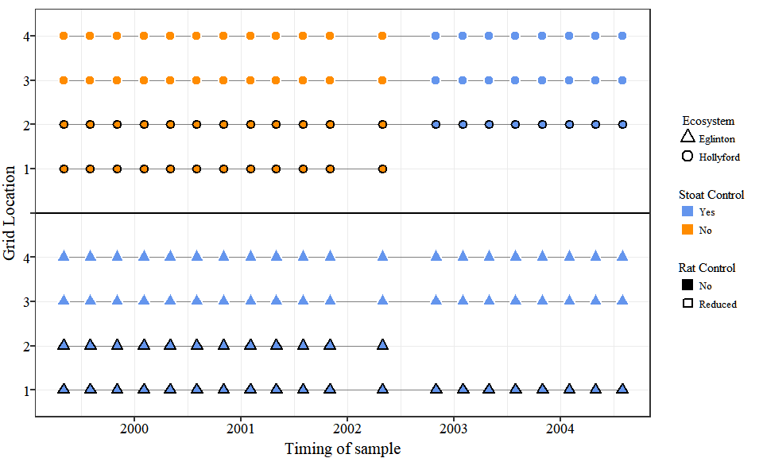

### Saving

## Seed

### Data

### Plot

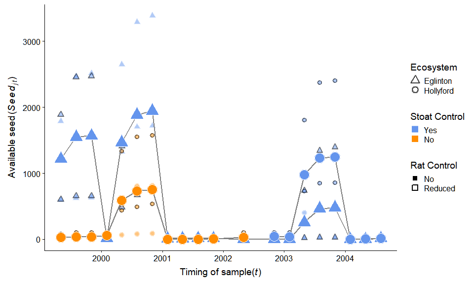

### Saving

#### Data

#### Figure

## Mice

### Data

### Plot

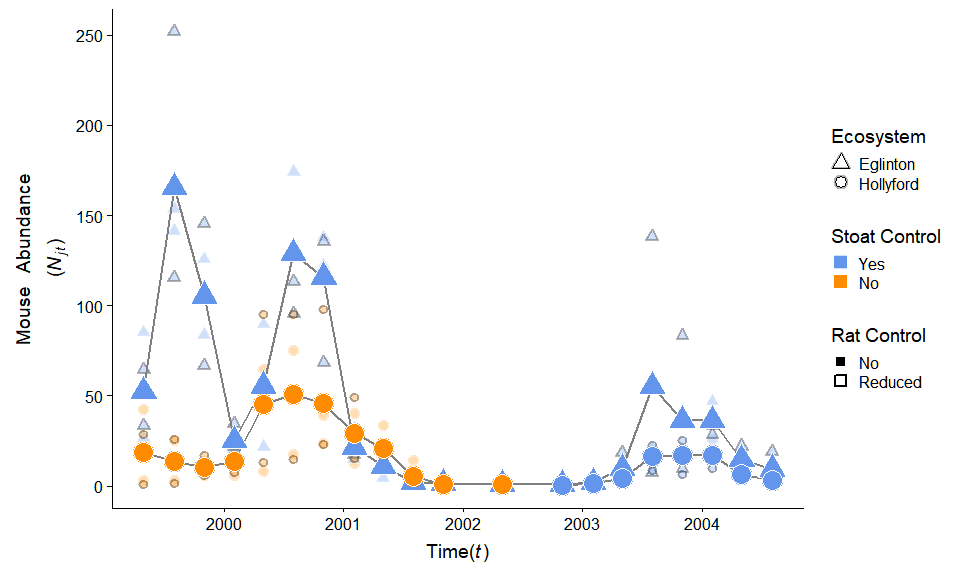

### Saving

## Rats

### Data

### Plot

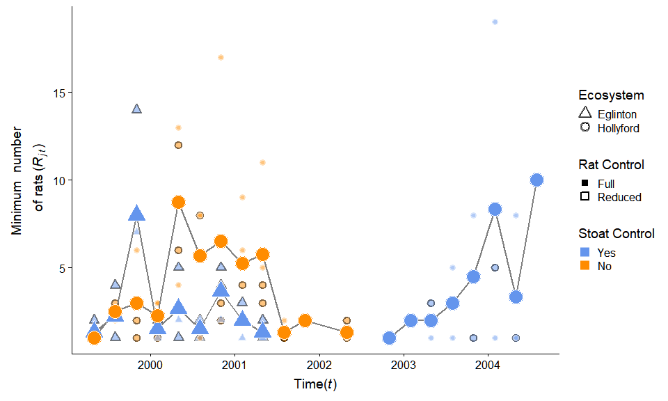

### Saving

# References

# Appendix

## A1: Extend seed analysis

### Descriptive plots

#### Temporal variation in seed

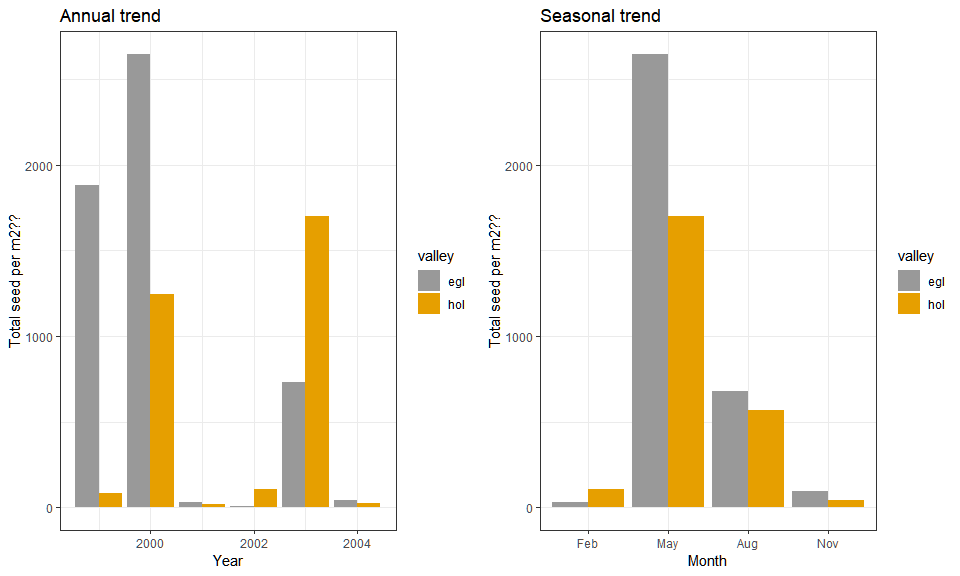

#### Tree `~spp`

But there could be more to this because there are differences between the different types of seed and the two valley systems

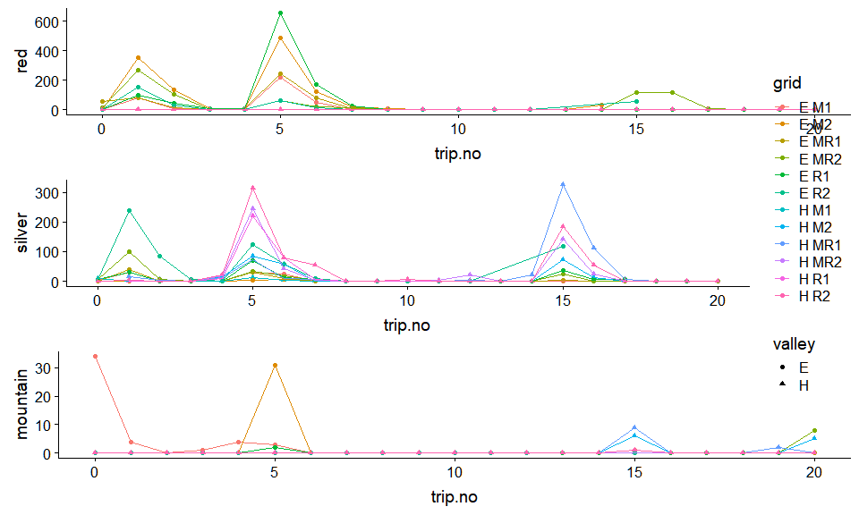

### Spatial variation in seed

We have replicated spatial areas in two ways in our study. We have replicated ecosystems (Valleys) twice and replicated six grids within each one.

### `~valley`

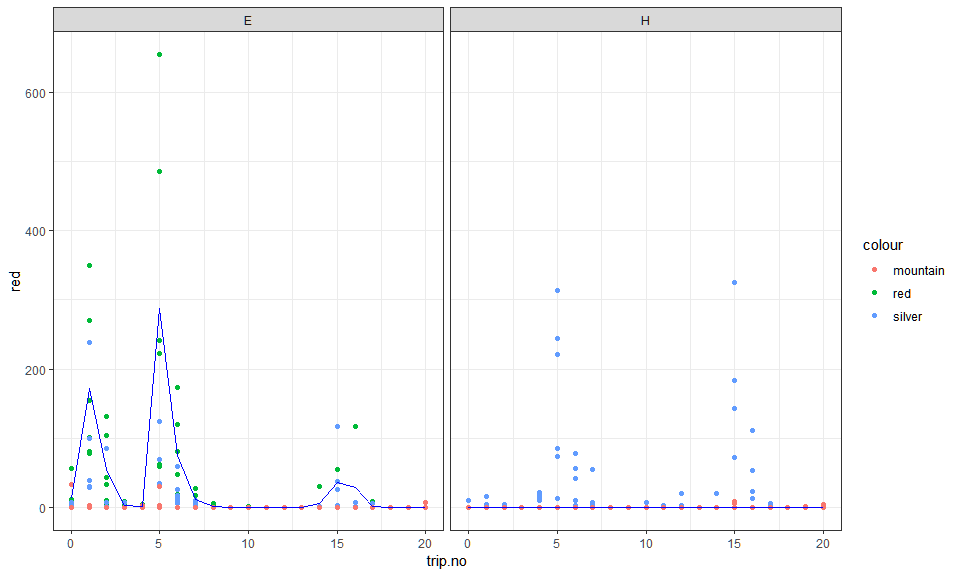

This shows that infact there are differences in the forest composition of the two valleys that have differences in control of stoats.

This is important because differences or lack of differences in the two valleys may simply be due to the different forest compositions rather than the removal of stoats from one system.

### `~grid`

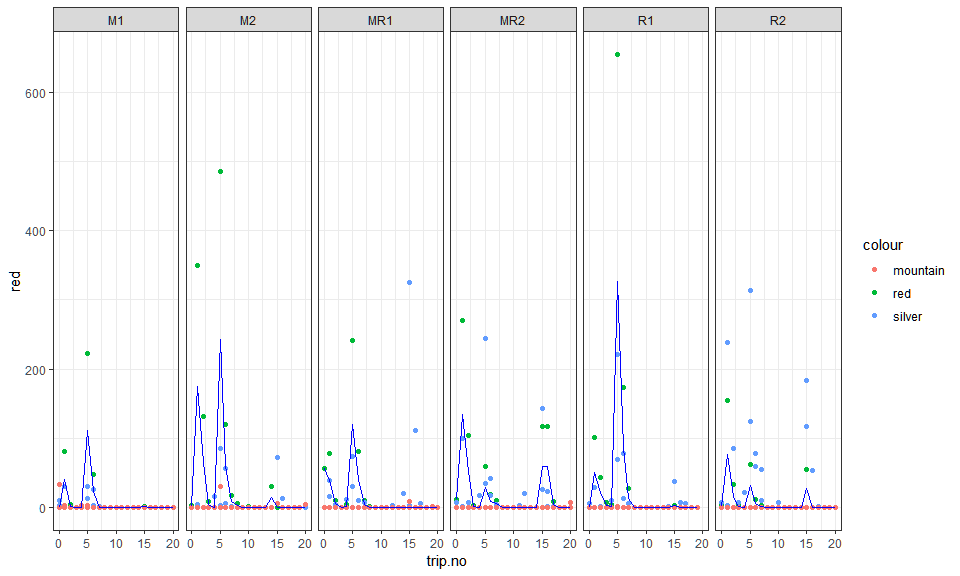

#### From the finalised dataset

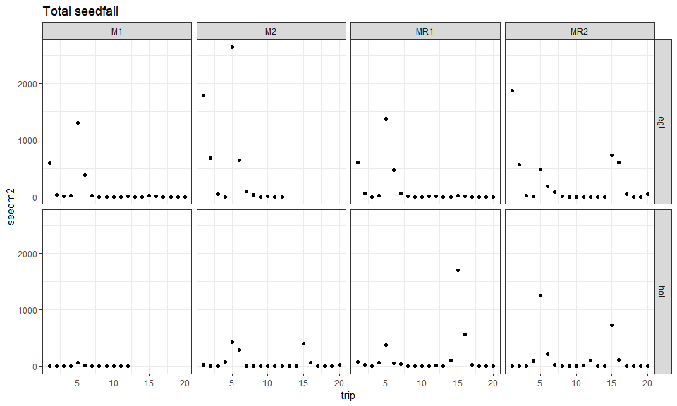

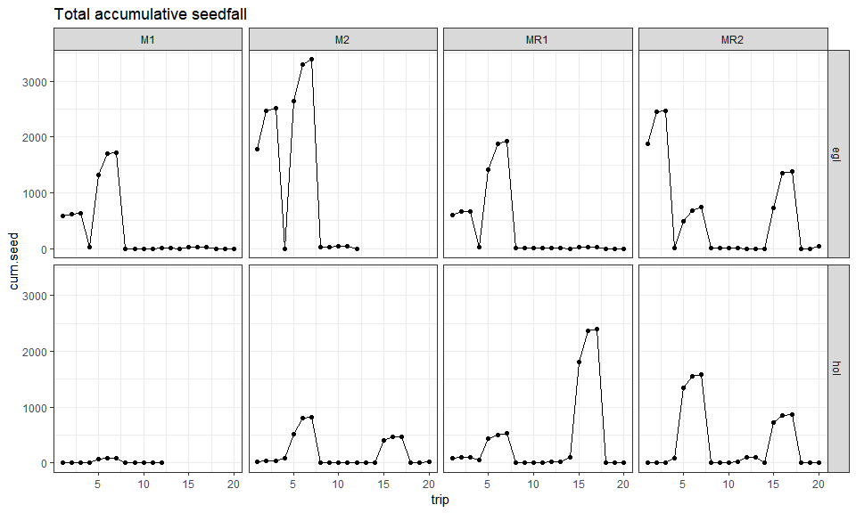

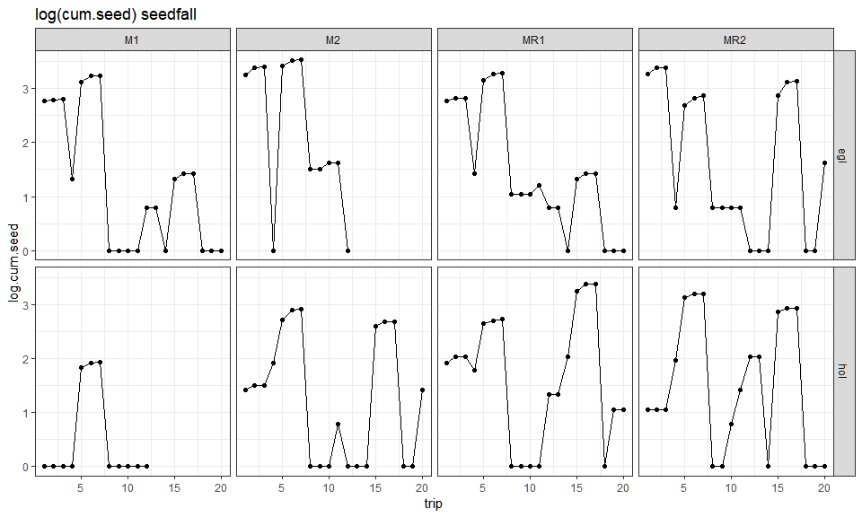

## A2: Bug fixes

**THIS IS the error…** Over the past … ages I have had issues with factors, characters and merging datasets. Here is where the biggest error in my analysis is found. I have worked through it below (to my shame!)

### Issue 1

#### Solution!

I have manually fixed the manuscript code here when merging seed and N. **Above no-longer is an issue using the Tidyverse set of tools (Ross, Wickham, and Robinson 2017).**

### Questions still needing asked

1. log of -inf needs to be replaced with zero before analysis?

### Notes

- There is NO red beech recorded in the Hollyford valley
- There is larger peaks of overall food in the Eglinton Valley compared to the Hollyford

Choquenot, David, and Wendy A Ruscoe. 2000. “Mouse Population Eruptions in New Zealand Forests: The Role of Population Density and Seedfall.” *Journal of Animal Ecology* 69: 1058–70.

Kellner, Ken. 2018. *jagsUI: A Wrapper Around ’Rjags’ to Streamline ’JAGS’ Analyses*.

King, Carolyn M. 1983. “The Relationships Between Beech (Nothofagus Sp.) Seedfall and Populations of Mice (Mus Musculus), and the Demographic and Dietary Responses of Stoats (Mustela Erminea), in Three New Zealand Forests.” *Journal of Animal Ecology* 52 (1): 141–66.

Ross, Zev, Hadley Wickham, and David Robinson. 2017. “Declutter Your R Workflow with Tidy Tools.” Preprint. PeerJ Preprints. https://doi.org/10.7287/peerj.preprints.3180v1.

Ruscoe, Wendy A, Joseph S Elkinton, David Choquenot, and Robert B Allen. 2005. “Predation of Beech Seed by Mice: Effects of Numerical and Functional Responses.” *Journal of Animal Ecology* 74: 1005–19. https://doi.org/10.1111/j.1365-2656.2005.00998.x.

Ruscoe, Wendy A, Ruth Goldsmith, and David Choquenot. 2001. “A Comparison of Population Estimates and Abundance Indices for House Mice Inhabiting Beech Forests in New Zealand.” *Wildlife Research* 28: 173–78.

Wardle, P. 1991. *Vegetation of New Zealand*. Cambridge University Press.